# HW5_network

Yuting

2024-10-24

# Data Loading

```r
library(widyr)
library(tidyverse)
```

```r
library(igraph)
library(ggraph)
library(plyr)
library(readtext)
library(tidytext)
```

```r
main_folder <- "trade pubs-962"

all_files <- list.files(main_folder, pattern = "\\.docx$", full.names = TRUE, recursive = TRUE)

data <- readtext(all_files)
glimpse(data)
```

```
## Rows: 962
## Columns: 2
## $ doc_id <chr> "A catastrophic year for the media in Myanmar.docx", "A kind of…
## $ text   <chr> "A catastrophic year for the media in Myanmar\nAbout a month ag…
```

# Data Processing

## Tokenization

```r
data_tokenized <- data %>%
  unnest_tokens(word, text, to_lower = TRUE) #text as variable

glimpse(data_tokenized)
```

```
## Rows: 1,275,317
## Columns: 2
## $ doc_id <chr> "A catastrophic year for the media in Myanmar.docx", "A catastr…
## $ word   <chr> "a", "catastrophic", "year", "for", "the", "media", "in", "myan…
```

## Customize Stopwords

```r
final_stop <- data.frame(word = c("journalists", "media", "news", "journalist", "journalism", "country", "including", "based", "told", "it’s", "day", "el", "al", "der", "und", "don’t","n","i’m","doesn’t","de","we’ve","id","country’s","that’s","we’re","what’s","you’re","i’ve","ten","myanmar’s","chin","pu",",",".","..","th","s"), lexicon = "custom") %>%
  bind_rows(stop_words)

data_clean <- data_tokenized %>%
  anti_join(final_stop) %>%
  mutate(word = gsub("[0-9]+", "", word)) %>%
  filter(word != "")
colnames(data_clean)
```

```
## [1] "doc_id" "word"
```

```r
data_clean %>%
  dplyr::count(word, sort=TRUE)
```

```
## readtext object consisting of 58167 documents and 0 docvars.
## # A data frame: 58,167 × 3
##   word              n text
##   <chr>         <int> <chr>
## 1 exile          2523 "\"\"..."
## 2 government     2285 "\"\"..."
## 3 press          2278 "\"\"..."
## 4 people         2242 "\"\"..."
## 5 russian        2179 "\"\"..."
## 6 investigative  1990 "\"\"..."
## # ℹ 58,161 more rows
```

## Filter Data

```r
library(dplyr)

frequent_words <- data_clean %>%
  dplyr::count(word, sort = TRUE) %>%
  filter(n > 100)

data_filtered <- data_clean %>%
  semi_join(frequent_words, by = "word")

glimpse(data_filtered)
```

```
## Rows: 300,206
## Columns: 2
## $ doc_id <chr> "A catastrophic year for the media in Myanmar.docx", "A catastr…
## $ word   <chr> "myanmar", "month", "ago", "experienced", "close", "borders", "…
```

## Construct Co-occurance Network

```r
doc_word_pairs <- data_filtered %>%
  widyr::pairwise_count(word, doc_id, sort = TRUE)
```

```r
word_graph <- graph_from_data_frame(doc_word_pairs, directed = FALSE)

word_graph
```

```
## IGRAPH a4084aa UN-- 1116 1204300 --
## + attr: name (v/c), n (e/n)
## + edges from a4084aa (vertex names):
##  [1] freedom   --press       freedom   --press       press     --exile
##  [4] press     --exile       exile     --government  exile     --government
##  [7] freedom   --exile       freedom   --exile       exile     --independent
## [10] exile     --independent press     --government  press     --government
## [13] government--time        government--time        freedom   --government
## [16] freedom   --government  exile     --time        exile     --time
## [19] government--people      time      --people      government--people
## [22] time      --people      press     --independent press     --independent
## + ... omitted several edges
```

```r
glimpse(doc_word_pairs)
```

```
## Rows: 1,204,300
## Columns: 3
## $ item1 <chr> "freedom", "press", "exile", "press", "exile", "government", "ex…
## $ item2 <chr> "press", "freedom", "press", "exile", "government", "exile", "fr…
## $ n     <dbl> 456, 456, 454, 454, 450, 450, 428, 428, 417, 417, 415, 415, 402,…
```

# Data Visualization

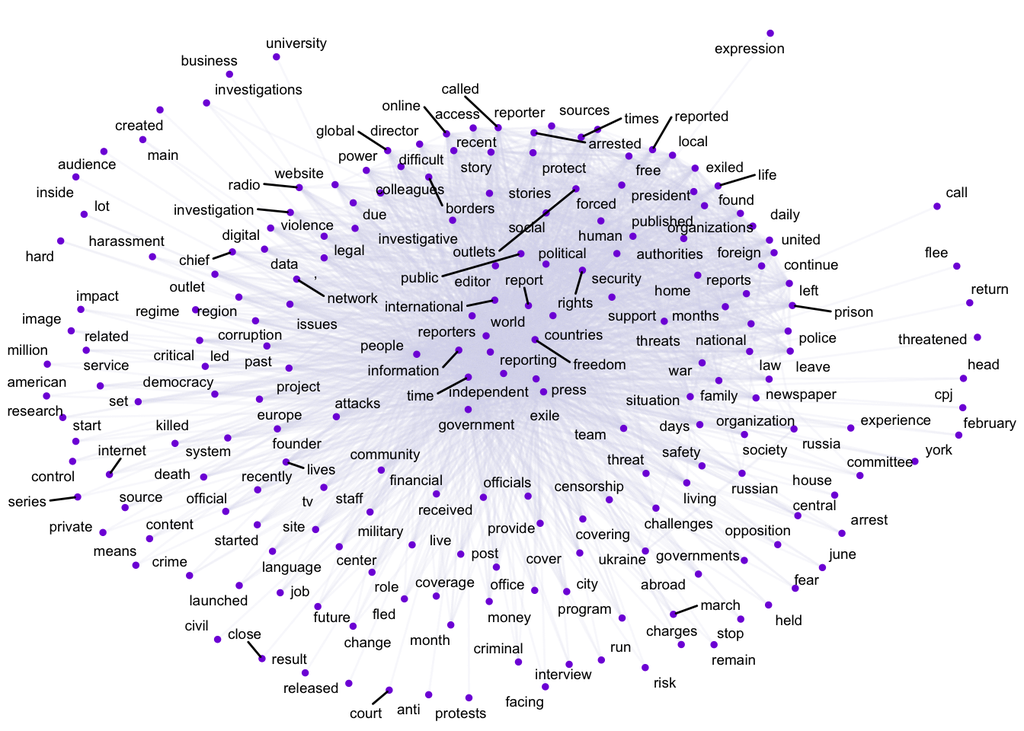

```r
doc_word_pairs %>%
  filter(n>= 150) %>%
  graph_from_data_frame() %>%
  ggraph(layout = "kk") +
    geom_edge_link(aes(edge_alpha = n), edge_colour = "#d9d2e9", edge_alpha = 0.08, show.legend = FALSE) +
    geom_node_point(color =  "#8029dc", size = 1) +
    geom_node_text(aes(label = name), repel = TRUE, size = 2.5, max.overlaps = 6000) +
    theme_void()
```

# Community Detection

## Using Louvain Alogrithm

```r
#Louvain algorithm
word_graph <- graph_from_data_frame(doc_word_pairs %>% filter(n >= 150), directed = FALSE)
clusters <- cluster_louvain(word_graph)
```

## Data Visualization

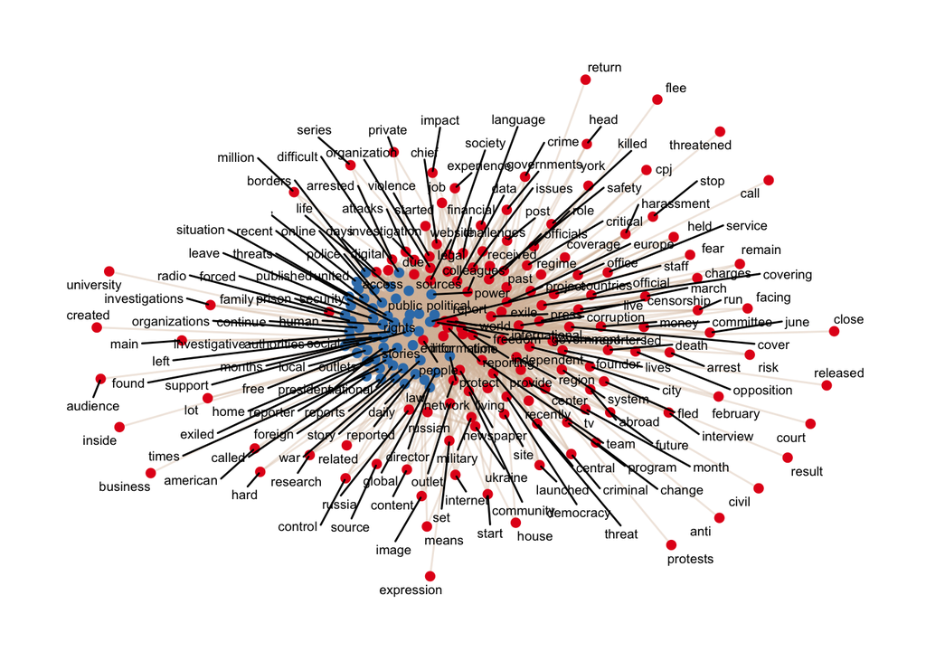

```r
#plot
ggraph(word_graph, layout = "fr") +
  geom_edge_link(edge_colour = "#d6bea5", edge_alpha = 0.2, show.legend = FALSE) +
  geom_node_point(aes(color = as.factor(membership(clusters))), size = 2) +
  geom_node_text(aes(label = name), repel = TRUE, size = 2.5, max.overlaps = 1000) +
  scale_color_brewer(palette = "Set1") +
  theme_graph() +
  theme(legend.position = "none")
```

# Brief Conclusion

The dataset is scraped from nine international NGO journalism websites, each containing articles on global exiled journalism. As attention grows around the human rights issues faced by exiled journalists, the journalism community has shown increasing concern globally. However, academic awareness to support exiled journalists remains disproportionately low. For an upcoming final analysis, I aim to merge this dataset with prior limited scholarly research to create a comprehensive view of current knowledge and especially to highlight what is missing in the global exiled journalism landscape. The result will be used for an introductory section in a potential ICA “blue sky” session.

To explore the dataset, I plan to use unsupervised machine learning method to cluster themes in the text. For this stage (HW5), I construct a co-occurrence network at the article level and apply the Louvain algorithm for community detection.

Although topic modeling is likely a better-suited method for the research goal, this initial homework exercise will provide an useful “hunch” for future topic modeling work.

In this homework, the variable is the “text” of each article. Then at the word level, a network of word pairs is constructed. Given the exponential growth of word-pair combinations, I chose to filter the dataset using frequency cutoffs: individual words appear at least 100 times, and word pairs appear at least 150 times. The cutoff values require further validation for more rigorous future research. Ultimately, I believe topic modeling with qualitative validation will be a more suitable method.